# Avaliação de Cafés

Flávio Barbosa Shirahige, Hélio Pereira de Oliveira e Michel Maurice Conjaud Neto

2023-11-24

```r
knitr::opts_chunk$set(echo = TRUE, cache = TRUE)
library(MASS)
library(tidyverse)
library(keras)
library(rsample)
library(keras)
library(yardstick)
library(skimr)
library(dplyr)
library(GGally)
library(ggrepel)
library(factoextra)
library(countrycode)
library(dplyr)
library(tidymodels)
library(tidyverse)
library(ISLR)
library(vip)
library(doParallel)
library(skimr)
library(corrplot)
library(caret)
```

## Introdução

Inicialmente, o objetivo desse projeto é prever o pontuação/score da avaliação de cafés a partir das demais preditoras do dataset (análise supervisionada) e agrupar os tipos de café a partir da qualidade do café (análise não supervisionada).

No entanto, a pontuação/score final de um café é a simples somatória das notas de cada uma das qualidades avaliadas. Assim, a nota final é simplesmente uma modelo linear das variáveis de qualidades de café, tornando-se um modelo com erro quase zero.

Assim, optou-se por construir um modelo de classificação que tenta prever a qualidade do café para quatro diferentes níveis: ruim, bom,muito bom e excelente. Para tal, não serão utilizadas nesse processo de modelagem as variáveis que compõe a nota final dos café. Logo, visa-se prever a qualidade do café a partir de outras características do mesmo, como local, tipo de café, grão etc.

Nesse projeto será utilizada a base de dados com informações de qualidade de café coletadas das avaliações do Coffee Quality Institute de Janeiro de 2018. A avaliação dos café é feita a partir de diversas características do café, como acidez, doçura, equilíbrio etc. e é pontuada numa escala de 0 a 100. Para os modelos supervisionados, foi criada uma variável resposta a partir dessa pontuação, onde:

- Pontuação menor do que 70: Ruim (será considerado como 0)
- Pontuação maior do que 70 e menor do que 80: Bom (será considerado como 1)
- Pontuação maior do que 80 e menor do que 85: Muito Bom (será considerado como 2)
- Pontuação maior do que 85: Excelente (será considerado como 3)

Esse critério segue o padrão dos principais institutos que avaliam cafés.

Além disso, como forma de comparação com a abordagem multinomial, será criada uma variável resposta para classificar os cafés em dois tipos (bom e ruim) e será aplicado o modelo de regressão logística. Nesta variável resposta, os cafés com pontuação acima de 80 serão será definido como Very Good e os demais como Not Very Good.

- Aroma grade
- Flavor grade
- Aftertaste grade
- Acidity grade
- Body grade
- Balance grade
- Uniformity grade
- Clean cup grade
- Sweetness grade
- Cupper Points

## Tratamento e Análise Exploratória dos Dados

Inicialmente, serão importados os dados:

```r
#conflicts_prefer(dplyr::select)
df <- read.csv("https://raw.githubusercontent.com/mconjaud/TrabalhoFinalAEM2/main/Estatistica/coffee_ratings.csv")
```

O próximo passo é explorar os dados.

```r
skim(df) # descritiva dos dados
```

Data summary

| Name | df |
| --- | --- |
| Number of rows | 1339 |
| Number of columns | 43 |
| _______________________ |  |
| Column type frequency: |  |
| character | 24 |
| numeric | 19 |
| ________________________ |  |
| Group variables | None |

**Variable type: character**

| skim_variable | n_missing | complete_rate | min | max | empty | n_unique | whitespace |
| --- | --- | --- | --- | --- | --- | --- | --- |
| species | 0 | 1.00 | 7 | 7 | 0 | 2 | 0 |
| owner | 7 | 0.99 | 3 | 50 | 0 | 315 | 0 |
| country_of_origin | 1 | 1.00 | 4 | 28 | 0 | 36 | 0 |
| farm_name | 359 | 0.73 | 1 | 73 | 0 | 571 | 0 |
| lot_number | 1063 | 0.21 | 1 | 71 | 0 | 227 | 0 |
| mill | 315 | 0.76 | 1 | 77 | 0 | 460 | 0 |
| ico_number | 151 | 0.89 | 1 | 40 | 0 | 847 | 0 |
| company | 209 | 0.84 | 3 | 73 | 0 | 281 | 0 |
| altitude | 226 | 0.83 | 1 | 41 | 0 | 396 | 0 |
| region | 59 | 0.96 | 2 | 76 | 0 | 356 | 0 |
| producer | 231 | 0.83 | 1 | 100 | 0 | 691 | 0 |
| bag_weight | 0 | 1.00 | 1 | 8 | 0 | 56 | 0 |
| in_country_partner | 0 | 1.00 | 7 | 85 | 0 | 27 | 0 |
| harvest_year | 47 | 0.96 | 3 | 24 | 0 | 46 | 0 |
| grading_date | 0 | 1.00 | 13 | 20 | 0 | 567 | 0 |
| owner_1 | 7 | 0.99 | 3 | 50 | 0 | 319 | 0 |
| variety | 226 | 0.83 | 4 | 21 | 0 | 29 | 0 |
| processing_method | 170 | 0.87 | 5 | 25 | 0 | 5 | 0 |
| color | 218 | 0.84 | 4 | 12 | 0 | 4 | 0 |
| expiration | 0 | 1.00 | 13 | 20 | 0 | 566 | 0 |
| certification_body | 0 | 1.00 | 7 | 85 | 0 | 26 | 0 |
| certification_address | 0 | 1.00 | 40 | 40 | 0 | 32 | 0 |
| certification_contact | 0 | 1.00 | 40 | 40 | 0 | 29 | 0 |
| unit_of_measurement | 0 | 1.00 | 1 | 2 | 0 | 2 | 0 |

**Variable type: numeric**

| skim_variable | n_missing | complete_rate | mean | sd | p0 | p25 | p50 | p75 | p100 | hist |
| --- | --- | --- | --- | --- | --- | --- | --- | --- | --- | --- |
| total_cup_points | 0 | 1.00 | 82.09 | 3.50 | 0 | 81.08 | 82.50 | 83.67 | 90.58 | ▁▁▁▁▇ |
| number_of_bags | 0 | 1.00 | 154.18 | 129.99 | 0 | 14.00 | 175.00 | 275.00 | 1062.00 | ▇▇▁▁▁ |
| aroma | 0 | 1.00 | 7.57 | 0.38 | 0 | 7.42 | 7.58 | 7.75 | 8.75 | ▁▁▁▁▇ |
| flavor | 0 | 1.00 | 7.52 | 0.40 | 0 | 7.33 | 7.58 | 7.75 | 8.83 | ▁▁▁▁▇ |
| aftertaste | 0 | 1.00 | 7.40 | 0.40 | 0 | 7.25 | 7.42 | 7.58 | 8.67 | ▁▁▁▁▇ |
| acidity | 0 | 1.00 | 7.54 | 0.38 | 0 | 7.33 | 7.58 | 7.75 | 8.75 | ▁▁▁▁▇ |
| body | 0 | 1.00 | 7.52 | 0.37 | 0 | 7.33 | 7.50 | 7.67 | 8.58 | ▁▁▁▁▇ |
| balance | 0 | 1.00 | 7.52 | 0.41 | 0 | 7.33 | 7.50 | 7.75 | 8.75 | ▁▁▁▁▇ |
| uniformity | 0 | 1.00 | 9.83 | 0.55 | 0 | 10.00 | 10.00 | 10.00 | 10.00 | ▁▁▁▁▇ |
| clean_cup | 0 | 1.00 | 9.84 | 0.76 | 0 | 10.00 | 10.00 | 10.00 | 10.00 | ▁▁▁▁▇ |
| sweetness | 0 | 1.00 | 9.86 | 0.62 | 0 | 10.00 | 10.00 | 10.00 | 10.00 | ▁▁▁▁▇ |
| cupper_points | 0 | 1.00 | 7.50 | 0.47 | 0 | 7.25 | 7.50 | 7.75 | 10.00 | ▁▁▁▇▁ |
| moisture | 0 | 1.00 | 0.09 | 0.05 | 0 | 0.09 | 0.11 | 0.12 | 0.28 | ▃▇▅▁▁ |
| category_one_defects | 0 | 1.00 | 0.48 | 2.55 | 0 | 0.00 | 0.00 | 0.00 | 63.00 | ▇▁▁▁▁ |
| quakers | 1 | 1.00 | 0.17 | 0.83 | 0 | 0.00 | 0.00 | 0.00 | 11.00 | ▇▁▁▁▁ |
| category_two_defects | 0 | 1.00 | 3.56 | 5.31 | 0 | 0.00 | 2.00 | 4.00 | 55.00 | ▇▁▁▁▁ |
| altitude_low_meters | 230 | 0.83 | 1750.71 | 8669.44 | 1 | 1100.00 | 1310.64 | 1600.00 | 190164.00 | ▇▁▁▁▁ |
| altitude_high_meters | 230 | 0.83 | 1799.35 | 8668.81 | 1 | 1100.00 | 1350.00 | 1650.00 | 190164.00 | ▇▁▁▁▁ |
| altitude_mean_meters | 230 | 0.83 | 1775.03 | 8668.63 | 1 | 1100.00 | 1310.64 | 1600.00 | 190164.00 | ▇▁▁▁▁ |

```r
#Não há dados faltantes, logo não é necessário o tratamento para completar a base
summary(df)
```

```
##  total_cup_points   species             owner           country_of_origin
##  Min.   : 0.00    Length:1339        Length:1339        Length:1339
##  1st Qu.:81.08    Class :character   Class :character   Class :character
##  Median :82.50    Mode  :character   Mode  :character   Mode  :character
##  Mean   :82.09
##  3rd Qu.:83.67
##  Max.   :90.58
##
##   farm_name          lot_number            mill            ico_number
##  Length:1339        Length:1339        Length:1339        Length:1339
##  Class :character   Class :character   Class :character   Class :character
##  Mode  :character   Mode  :character   Mode  :character   Mode  :character
##
##
##
##
##    company            altitude            region            producer
##  Length:1339        Length:1339        Length:1339        Length:1339
##  Class :character   Class :character   Class :character   Class :character
##  Mode  :character   Mode  :character   Mode  :character   Mode  :character
##
##
##
##
##  number_of_bags    bag_weight        in_country_partner harvest_year
##  Min.   :   0.0   Length:1339        Length:1339        Length:1339
##  1st Qu.:  14.0   Class :character   Class :character   Class :character
##  Median : 175.0   Mode  :character   Mode  :character   Mode  :character
##  Mean   : 154.2
##  3rd Qu.: 275.0
##  Max.   :1062.0
##
##  grading_date         owner_1            variety          processing_method
##  Length:1339        Length:1339        Length:1339        Length:1339
##  Class :character   Class :character   Class :character   Class :character
##  Mode  :character   Mode  :character   Mode  :character   Mode  :character
##
##
##
##
```

[output cut: 33 more lines]

```
##  Length:1339           Length:1339           Length:1339
##  Class :character      Class :character      Class :character
##  Mode  :character      Mode  :character      Mode  :character
##
##
##
##
##  altitude_low_meters altitude_high_meters altitude_mean_meters
##  Min.   :     1      Min.   :     1       Min.   :     1
##  1st Qu.:  1100      1st Qu.:  1100       1st Qu.:  1100
##  Median :  1311      Median :  1350       Median :  1311
##  Mean   :  1751      Mean   :  1799       Mean   :  1775
##  3rd Qu.:  1600      3rd Qu.:  1650       3rd Qu.:  1600
##  Max.   :190164      Max.   :190164       Max.   :190164
##  NA's   :230         NA's   :230          NA's   :230
```

Abaixo, será plotado o gráfico com o percentual de valores faltantes (missing values):

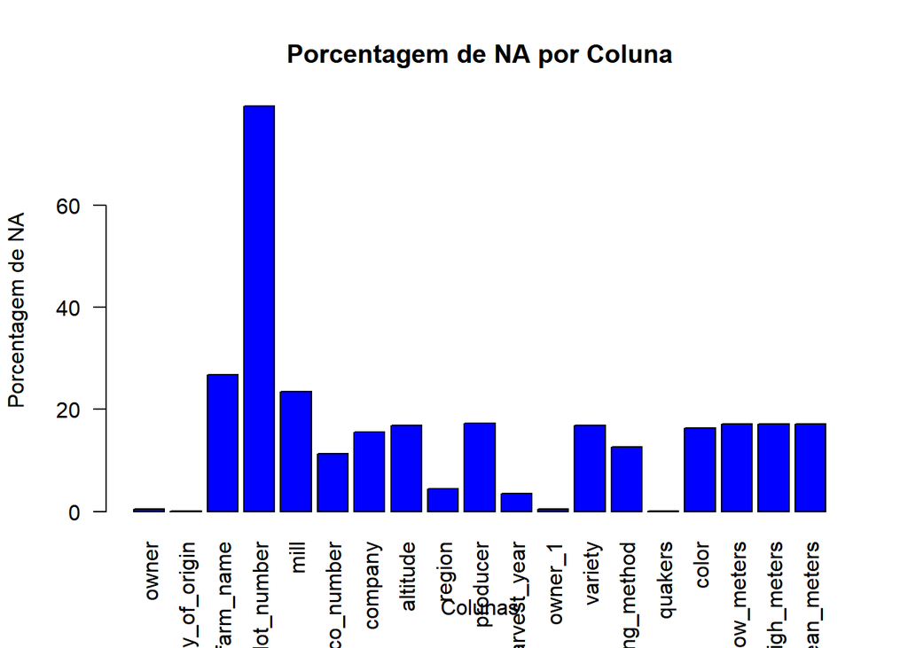

```r
colunas_na <- colSums(is.na(df))
info_na <- colunas_na[colunas_na > 0] # 4 colunas com NA
porcent_NA <- info_na / nrow(df) * 100

barplot(porcent_NA, main = "Porcentagem de NA por Coluna",
        ylab = "Porcentagem de NA", xlab = "Colunas",
        col = "blue", las = 2)  # las = 2 para rotacionar os rótulos do eixo x
```

### Tratamento dos Dados

Inicialmente, serão removidos as linhas com missing values da coluna country_of_origin, pois essa linha tem pouca informação:

```r
df <- df[complete.cases(df$country_of_origin), ]
```

O passo seguinte é excluir as variáveis que não serão utilizadas no processo de modelagem. Serão excluídas algumas variáveis categóricas que não trazerem informação relevante para a qualidade do café, especialmente aqueles relacionadas ao produtor, certificador, tamanho do lote e local de produção do café. Também serão excluídas as variáveis de data (harvest_year, grading_date, expiration), seja pela qualidade das informações, seja pelo número elevado de valores faltantes. Além destas, foram desconsideradas na modelagem as variáveis altitude_low_meters e altitude_high_meters, pois serem informações já constantes na altitude_mean_meters. No mais, informações que poderiam ser relevantes, mas que possuem baixa qualidade, também foram descartadas: region (muitos valores distintos e com informações em caracteres que não são do alfabeto ocidental).

```r
coffee <- subset (df,
                  select = -c(owner
                              ,farm_name
                              ,lot_number
                              ,mill
                              ,ico_number
                              ,company
                              ,altitude
                              ,region
                              ,producer
                              ,number_of_bags
                              ,bag_weight
                              ,in_country_partner
                              ,harvest_year
                              ,grading_date
                              ,owner_1
                              ,expiration
                              ,certification_body
                              ,certification_address
                              ,certification_contact
                              ,altitude_low_meters
                              ,altitude_high_meters))
```

A próxima etapa é tratar os missing values das variáveis restantes. Para a variável processing_method, será considerada o valor mais frequente, isto é, “Washed / Wet”:

```r
coffee <- coffee %>%
  mutate(processing_method =
           ifelse(is.na(processing_method), "Washed / Wet", processing_method))
```

Para a variável color, os missing values foram substituídos por “green”, a moda dessa coluna:

```r
coffee <- coffee %>%
  mutate(color = ifelse(is.na(color), "Green", color))
```

Na coluna altitude_mean_meters será necessário tratar os missing values e a depadronização dos valores, uma vez que os mesmos estão em metros (m) ou pés (ft). Inicialmente será convertida a coluna altitude_mean_meters de pés para metros, quando aplicável:

```r
coffee<- coffee %>%
  mutate(altitude_mean_meters = ifelse(unit_of_measurement == "ft", altitude_mean_meters * 0.3048, altitude_mean_meters))
```

Além do problema citado acima, também há problema com qualidade da informação, já que existem valores acima dos 10.000 (mais alto que o Everest). Assim, esses valores serão divididos por 100 (valores acima dos 100.000) e por 10 (acima dos 5000), nessa sequência:

```r
coffee<- coffee %>%
  mutate(altitude_mean_meters = ifelse(altitude_mean_meters > 100000, altitude_mean_meters/100, altitude_mean_meters))

coffee<- coffee %>%
  mutate(altitude_mean_meters = ifelse(altitude_mean_meters > 5000, altitude_mean_meters/10, altitude_mean_meters))
```

Tratados os dados de altitude_mean_meters, será feito o preenchimento dos missings desta coluna pela média por país:

```r
coffee <- coffee %>%
  group_by(country_of_origin) %>%
  mutate(altitude_mean_meters = ifelse(is.na(altitude_mean_meters),
                                       mean(altitude_mean_meters, na.rm = TRUE),
                                       altitude_mean_meters))
```

Para a variável quakers, os missing values foram substituídos pela moda dessa coluna:

```r
coffee$quakers <- ifelse(is.na(coffee$quakers),
                         names(sort(-table(coffee$quakers)))[1], #calcula a moda
                         coffee$quakers)
```

Para a variável variety, serão substituídos pelo valor mais frequente (moda) por país (country_of_origin). No entanto, há exceções: a Costa do Marfim, Equador, Mauricios e Papua Nova Guine só possuem um café avaliado e não possui valores de variety. Para estes, será utilizada a moda da coluna inteira:

```r
coffee$variety <- ifelse(coffee$country_of_origin == "Cote d?Ivoire" |
                           coffee$country_of_origin == "Ecuador" |
                           coffee$country_of_origin == "Mauritius"|
                           coffee$country_of_origin == "Papua New Guinea",
                         names(sort(-table(coffee$variety)))[1], #calcula a moda
                         coffee$variety)
```

Agora, será criada uma tabela com a moda de variety por país (country_of_origin):

```r
moda_por_regiao <- coffee %>%
  group_by(country_of_origin) %>%
  summarise(moda_variety = names(sort(-table(variety)))[1])

moda_por_regiao <- na.omit(moda_por_regiao)
```

E abaixo serão substituídos os valores ausentes pelo valor mais frequente do país:

```r
coffee <- coffee %>%
  group_by(country_of_origin) %>%
  mutate(variety = ifelse(is.na(variety), moda_por_regiao$moda_variety[match(country_of_origin, moda_por_regiao$country_of_origin)], variety))
```

Além disso, para alguns paises estavam com “other” nesta coluna “variety”, será colocada a moda da variável

```r
coffee$variety <- ifelse(coffee$variety == "Other" ,
                         names(sort(-table(coffee$variety)))[1], #calcula a moda
                         coffee$variety)
```

Tratada base de dados, será removida a coluna unit_of_measurement, pois não será utilizada nos processos de modelagem supervisionada e não supervisionada.

```r
coffee <- subset(coffee, select = -c(unit_of_measurement))
```

### Variável Resposta dos Modelos Supervisionados

Abaixo será criada a coluna com a varável resposta (grade) para a abordagem multinomial, conforme definido acima:

```r
coffee$grade <- cut(coffee$total_cup_points,
                                    breaks = c(-Inf, 70, 80, 85, Inf),
                                    labels = c(0, 1, 2, 3),
                                    right = FALSE)
```

E abaixo será criada a coluna com a varável resposta (type) para uso na regressão logística, conforme definido acima:

```r
coffee$type <- ifelse(coffee$total_cup_points >= 80, "Very_Good", "Not_Very_Good")
```

### Proporção de Cafés por Faixa de Pontuação (Grade) e Análise de Colinearidade

#### Propoção

Abaixo, vamos plotar o gráfico para verificar a proporção de cafés por faixa (grade):

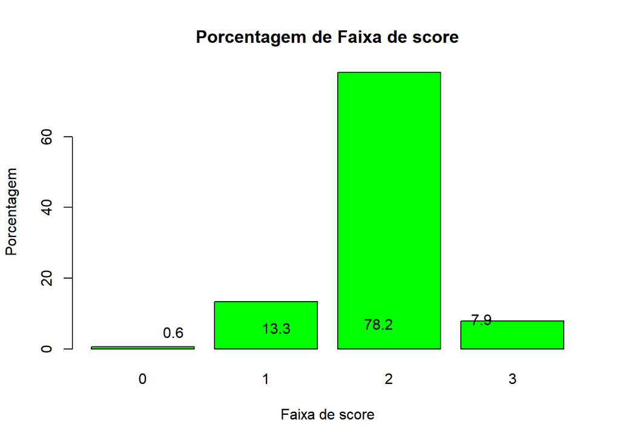

```r
contagem_faixas <- table(coffee$grade)

proporcao <- text(x = barplot(prop.table(contagem_faixas) * 100, main = "Porcentagem de Faixa de score",
                 xlab = "Faixa de score", ylab = "Porcentagem", col = "green"),
      labels = round(prop.table(contagem_faixas)* 100, 1), pos = 3)
```

```r
proporcao
```

#### Analise de Colinearidade

E em seguida vamos plotar a matriz de correlação das variáveis númericas:

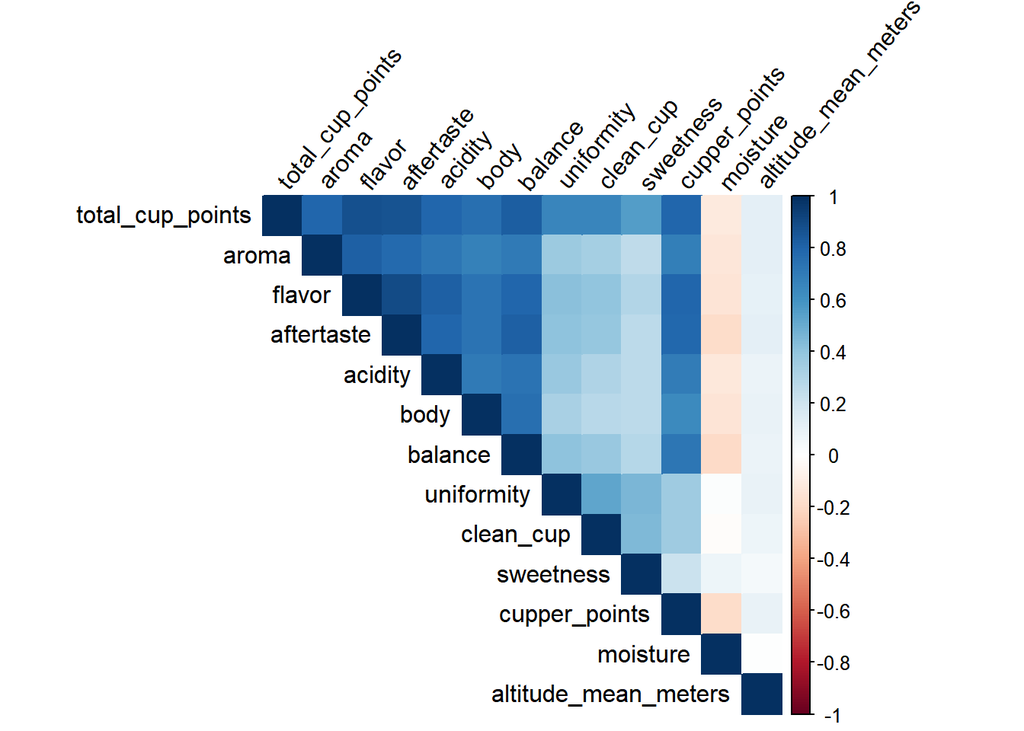

```r
# Calculando a matriz de correlação
dados <- coffee
colunas_nao_numericas <- sapply(dados, class) != "numeric"
dados_numericos <- dados[, !colunas_nao_numericas]
matrix_de_correlacao <- cor(dados_numericos)

options(repr.plot.width = 32, repr.plot.height = 32)
corrplot(matrix_de_correlacao, method = "color", type = "upper", tl.col = "black", tl.srt = 50)
```

Verifica-se que há alta correlação entre as variáveis de qualidade e a pontuação final do café (total_cup_point).

### Datasets para a Análise Supervisionada e Não Supervisionada.

Vamos criar dois datasets distintos, conforme definido acima:

- Análise Supervionada: coffee_grade
- Análise Não Supervionada: coffee_cluster

```r
coffee_grade <- subset(coffee, select = -c(total_cup_points,aroma,flavor,
                                          aftertaste,acidity,body,balance,
                                          uniformity,clean_cup,sweetness,
                                          cupper_points))

coffee_cluster <- subset(coffee, select = c(aroma,flavor,
                                            aftertaste,acidity,body,balance,
                                            uniformity,clean_cup,sweetness,
                                            cupper_points))
```

Agora, a etapa seguinte é criar os datasets de treinamento e teste que ser”ao utilizados tanto para a abordagem multinomial quanto para a regressão logística:

```r
set.seed(123)
split <- initial_split(coffee_grade, prop = 0.8, strata = grade)
training <- training(split)
test <- testing(split)
```

## Análise Supervisionada (Multinomial)

Nesse item serão construídos e analisados os modelos para prever a variável grade. São eles:

- Regressão Multinomial
- XGBoost
- Redes Neurais

Vamos remover a coluna type dos dados de treinamento e teste, já que esta será só utilizada no modelo de regressão logísitica:

```r
training_grade <- subset(training, select = -c(type))
test_grade <- subset(test, select = -c(type))
```

O primeiro passo é definir a receita, com a variavel resposta e os dados de treinamento, normalizando todas numericas exceto a variavel resposta e definindo variavel dummy para todas variaveis qualitativas.

```r
receita <- recipe(grade ~ ., data = training_grade) %>%
  step_normalize(all_numeric(), -all_outcomes()) %>%
  step_dummy(all_nominal(), -all_outcomes())
```

Abaixo, vamos preparar a receita definida acima:

```r
(receita_prep <- prep(receita))
```

```
## ── Recipe ──────────────────────────────────────────────────────────────────────
```

```
## ── Inputs
```

```
## Number of variables by role
```

```
## outcome:    1
## predictor: 10
```

```
## ── Training information
```

```
## Training data contained 1069 data points and no incomplete rows.
```

```
## ── Operations
```

```
## • Centering and scaling for: moisture, category_one_defects, ... | Trained
```

```
## • Dummy variables from: species, country_of_origin, variety, ... | Trained
```

Por fim, obtemos os dados de treinamento e teste processados:

```r
training_proc <- bake(receita_prep, new_data = NULL)
test_proc <- bake(receita_prep, new_data = test_grade)
```

### Tidymodels: Regressão MUltinomial

Primeiramente será definido o modelo de regressão multinomial:

```r
fit_mr <- multinom_reg(penalty = NULL , mixture = NULL) %>% # define um modelo de regressao Multinomial: pepenalty = 1 lasso \ 2 Ridge
  set_engine("nnet") %>%
  set_mode("classification") %>%
  fit(grade ~ ., training_proc)
```

Aplicando o modelo de previsão nos dados de teste e estimando os dados de previsão, armazenando os resultados do modelo numa tabela chamada fitted:

```r
fitted <- fit_mr %>%
  predict(new_data = test_proc) %>%
  mutate(observado = test_proc$grade,
         modelo = "Regressao Multinomial")

head(fitted)
```

```
## # A tibble: 6 × 3
##   .pred_class observado modelo
##   <fct>       <fct>     <chr>
## 1 3           3         Regressao Multinomial
## 2 2           3         Regressao Multinomial
## 3 2           3         Regressao Multinomial
## 4 2           3         Regressao Multinomial
## 5 3           3         Regressao Multinomial
## 6 3           3         Regressao Multinomial
```

E por último vamos definir a matriz de confusão desse modelo de regressão multinomial:

```r
matriz_confusao_mr <- confusionMatrix(fitted$.pred_class, fitted$observado)
```

### Tidymodels: XGBoost

O próximo modelo a ser estimado é o XGBoost. Inicialmente é definir o modelo e quais hiperparâmetros serão otimizados (trees = número de árvores, min_n = valor mínimo por nó, tree_depth = profundidade da árvore e learn_rate = taxa de aprendizagem do modelo):

```r
boost <- boost_tree(trees = tune(), min_n = tune(),
                    tree_depth = tune(), learn_rate = tune()) %>%
  set_engine("xgboost") %>%
  set_mode("classification")
```

Para esse processo de escolha dos hiperparâmetros, será utilizada a validação cruzada em 5 lotes:

```r
set.seed(123)
cv_split <- vfold_cv(training, v = 5)
registerDoParallel()
```

```r
boost_grid <- tune_grid(boost,
                        receita,
                        resamples = cv_split,
                        grid = 30,
                        metrics = metric_set(accuracy))

best <- boost_grid %>%
  select_best("accuracy")
```

Por fim será aplicado o modelo de previsão nos dados de teste e estimado os dados de previsão, armazenando numa tabela chamada fitted:

```r
boost_fit <- finalize_model(boost, parameters = best) %>%
  fit(grade ~ ., training_proc)

fitted_bst <- boost_fit %>%
  predict(new_data = test_proc) %>%
  mutate(observado = test_proc$grade,
         modelo = "XGBoost")

fitted <- fitted %>%
  bind_rows(fitted_bst)
```

E finalmente vamos definir a matriz de confusão desse modelo XGBoost:

```r
matriz_confusao_bst <- confusionMatrix(fitted_bst$.pred_class, fitted_bst$observado)
```

### Redes Neurais

O último modelo a ser estimado é o de Redes Neurais. Inicialmente, vamos transformar as variáveis preditoras de treinamento e teste em matriz:

```r
x_train <- training_proc %>%
  select(-grade) %>%
  as.matrix()

View(x_train)

x_test <- test_proc %>%
  select(-grade) %>%
  as.matrix()

x_train <- scale(x_train)

x_test <- scale(x_test,
               center = attr(x_train, "scaled:center"),
               scale = attr(x_train, "scaled:scale"))
```

Em seguida, a variável respost será transformada em categórica:

```r
y_train <- to_categorical(training_proc$grade)
y_test <- to_categorical(test_proc$grade)
```

Abaixo foi criada a estrutura da rede desse modelo, com quatro camadas intermediárias e a última com 4 unidades (4 valores de variável resposta esperados):

```r
net <- keras_model_sequential() %>%
  layer_dense(units = 64,
              activation = "relu",
              input_shape = ncol(x_train)) %>%
  layer_dropout(rate = 0.1) %>% # regularizacao para evitar overfitting
  layer_dense(units = 32, activation = "relu") %>%
  layer_dropout(rate = 0.1) %>%  # regularizacao para evitar overfitting
  layer_dense(units = 16, activation = "relu") %>%
  layer_dropout(rate = 0.1) %>%  # regularizacao para evitar overfitting
  layer_dense(units = 8, activation = "relu") %>%
  layer_dense(units = 4, activation = 'softmax')

summary(net)
```

```
## Model: "sequential"
## ________________________________________________________________________________
##  Layer (type)                       Output Shape                    Param #
## ================================================================================
##  dense_4 (Dense)                    (None, 64)                      5184
##  dropout_2 (Dropout)                (None, 64)                      0
##  dense_3 (Dense)                    (None, 32)                      2080
##  dropout_1 (Dropout)                (None, 32)                      0
##  dense_2 (Dense)                    (None, 16)                      528
##  dropout (Dropout)                  (None, 16)                      0
##  dense_1 (Dense)                    (None, 8)                       136
##  dense (Dense)                      (None, 4)                       36
## ================================================================================
## Total params: 7964 (31.11 KB)
## Trainable params: 7964 (31.11 KB)
## Non-trainable params: 0 (0.00 Byte)
## ________________________________________________________________________________
```

Compilando essa rede:

```r
net <- compile(net,
               loss = 'categorical_crossentropy',
               optimizer = "adam", #ver comentario abaixo
               metrics = c("accuracy") #pode ser customizada
)
```

e treinando o modelo:

```r
history <- fit(net, x_train, y_train,
               batch_size = 24, epochs = 30, # defaults: 32, 10
               validation_split = 0.2)
```

```
## 36/36 - 3s - loss: 1.5593 - accuracy: 0.1988 - val_loss: 1.3751 - val_accuracy: 0.5888 - 3s/epoch - 75ms/step
## 36/36 - 0s - loss: 1.3512 - accuracy: 0.5368 - val_loss: 1.2844 - val_accuracy: 0.7944 - 284ms/epoch - 8ms/step
## 36/36 - 0s - loss: 1.2712 - accuracy: 0.6082 - val_loss: 1.1675 - val_accuracy: 0.6168 - 245ms/epoch - 7ms/step
## 36/36 - 0s - loss: 1.1112 - accuracy: 0.5895 - val_loss: 0.9188 - val_accuracy: 0.9533 - 254ms/epoch - 7ms/step
## 36/36 - 0s - loss: 0.9287 - accuracy: 0.7287 - val_loss: 0.6497 - val_accuracy: 0.9766 - 247ms/epoch - 7ms/step
## 36/36 - 0s - loss: 0.8126 - accuracy: 0.7240 - val_loss: 0.5217 - val_accuracy: 0.9766 - 246ms/epoch - 7ms/step
## 36/36 - 0s - loss: 0.7504 - accuracy: 0.7298 - val_loss: 0.4746 - val_accuracy: 0.9673 - 293ms/epoch - 8ms/step
## 36/36 - 0s - loss: 0.7244 - accuracy: 0.7357 - val_loss: 0.4456 - val_accuracy: 0.9673 - 312ms/epoch - 9ms/step
## 36/36 - 0s - loss: 0.6980 - accuracy: 0.7392 - val_loss: 0.4586 - val_accuracy: 0.9626 - 245ms/epoch - 7ms/step
## 36/36 - 0s - loss: 0.6567 - accuracy: 0.7392 - val_loss: 0.4281 - val_accuracy: 0.9626 - 237ms/epoch - 7ms/step
## 36/36 - 0s - loss: 0.6388 - accuracy: 0.7474 - val_loss: 0.4271 - val_accuracy: 0.9626 - 247ms/epoch - 7ms/step
## 36/36 - 0s - loss: 0.6226 - accuracy: 0.7509 - val_loss: 0.4489 - val_accuracy: 0.9439 - 242ms/epoch - 7ms/step
## 36/36 - 0s - loss: 0.6037 - accuracy: 0.7591 - val_loss: 0.4970 - val_accuracy: 0.8692 - 235ms/epoch - 7ms/step
## 36/36 - 0s - loss: 0.6133 - accuracy: 0.7567 - val_loss: 0.4890 - val_accuracy: 0.8692 - 237ms/epoch - 7ms/step
## 36/36 - 0s - loss: 0.5925 - accuracy: 0.7637 - val_loss: 0.4863 - val_accuracy: 0.8692 - 261ms/epoch - 7ms/step
## 36/36 - 0s - loss: 0.5802 - accuracy: 0.7719 - val_loss: 0.5390 - val_accuracy: 0.8551 - 312ms/epoch - 9ms/step
## 36/36 - 0s - loss: 0.5498 - accuracy: 0.7778 - val_loss: 0.5856 - val_accuracy: 0.8411 - 235ms/epoch - 7ms/step
## 36/36 - 0s - loss: 0.5527 - accuracy: 0.7883 - val_loss: 0.5738 - val_accuracy: 0.8458 - 251ms/epoch - 7ms/step
## 36/36 - 0s - loss: 0.5498 - accuracy: 0.7918 - val_loss: 0.5473 - val_accuracy: 0.8551 - 284ms/epoch - 8ms/step
## 36/36 - 0s - loss: 0.5427 - accuracy: 0.7918 - val_loss: 0.6014 - val_accuracy: 0.8551 - 286ms/epoch - 8ms/step
## 36/36 - 0s - loss: 0.5371 - accuracy: 0.7871 - val_loss: 0.5782 - val_accuracy: 0.8505 - 245ms/epoch - 7ms/step
## 36/36 - 0s - loss: 0.5379 - accuracy: 0.7918 - val_loss: 0.6042 - val_accuracy: 0.8598 - 239ms/epoch - 7ms/step
## 36/36 - 0s - loss: 0.5124 - accuracy: 0.7988 - val_loss: 0.6576 - val_accuracy: 0.8318 - 337ms/epoch - 9ms/step
## 36/36 - 0s - loss: 0.5044 - accuracy: 0.7965 - val_loss: 0.6631 - val_accuracy: 0.8318 - 246ms/epoch - 7ms/step
## 36/36 - 0s - loss: 0.5076 - accuracy: 0.7906 - val_loss: 0.7105 - val_accuracy: 0.8271 - 246ms/epoch - 7ms/step
## 36/36 - 0s - loss: 0.4956 - accuracy: 0.7988 - val_loss: 0.7192 - val_accuracy: 0.8178 - 242ms/epoch - 7ms/step
## 36/36 - 0s - loss: 0.5038 - accuracy: 0.7988 - val_loss: 0.7397 - val_accuracy: 0.8178 - 246ms/epoch - 7ms/step
## 36/36 - 0s - loss: 0.4927 - accuracy: 0.8012 - val_loss: 0.7425 - val_accuracy: 0.8037 - 245ms/epoch - 7ms/step
## 36/36 - 0s - loss: 0.4862 - accuracy: 0.7953 - val_loss: 0.7153 - val_accuracy: 0.8178 - 334ms/epoch - 9ms/step
## 36/36 - 0s - loss: 0.4885 - accuracy: 0.8082 - val_loss: 0.7639 - val_accuracy: 0.8224 - 244ms/epoch - 7ms/step
```

```r
history
```

```
##
## Final epoch (plot to see history):
##         loss: 0.4885
##     accuracy: 0.8082
##     val_loss: 0.7639
## val_accuracy: 0.8224
```

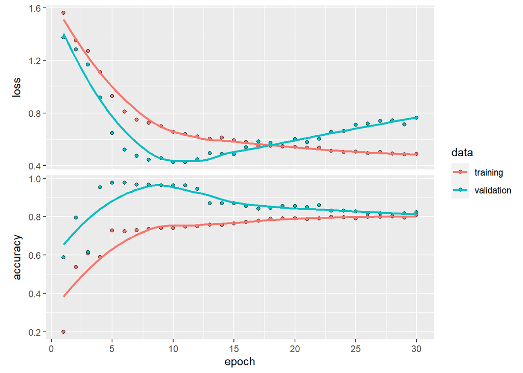

```r
plot(history)
```

Por último, vamos aplicar o modelo definido acima nos dados de teste e estimar os dados de previsão, armazenando numa tabela chamada fitted:

```r
pred_net <- net %>% predict(x_test) %>% k_argmax()%>% k_get_value()
```

```
## 9/9 - 0s - 223ms/epoch - 25ms/step
```

```r
fitted_net <- data.frame(.pred_class = factor(pred_net), observado = test_proc$grade, modelo = "Redes Neurais")

fitted <- fitted %>%
  bind_rows(fitted_net)
```

E abaixo vamos definir a matriz de confusão desse modelo de redes neurais:

```r
matriz_confusao_net <- confusionMatrix(fitted_net$.pred_class, fitted_net$observado)
```